# **第四章：聚类分析**

本章内容简介：

- 4.1 目的
- 4.2 聚类分析概论
- 4.3 层次聚类（基于连接）
- 4.4 平均聚合聚类
- 4.5 Ward最小方差聚类
- 4.6 柔性聚类
- 4.7 层次聚类结果的解释与比较
- 4.8 非层次聚类
- 4.9 比较环境数据
- 4.10 物种组合
- 4.11 指示性物种
- 4.12 多元回归树 (MRT): 约束性聚类
- 4.13 单元聚类方法 - MRT
- 4.14 连续性聚类
- 4.15 模糊聚类
- 4.16 结论

## 4.1 目的

前两章的探索性数据分析和关联分析是生态学相关数据进行深度分析的预处理过程. 通过本章对聚类分析的学习,以期达到以下几个目标:

- 学会如何选择恰当的聚类方法并学会如何使用该方法进行计算
- 使用不同的聚类方法分析 Doubs 河流数据集,从而确定位点数据集和鱼类物种数据集的聚类分析结果
- 探究性分析两种约束性聚类方法(由外部数据集约束的强有力的聚类分析方法)

## 4.2 聚类分析概论

聚类分析的主要目的是重新认识环境相关数据的不连续数据或者离散型数据(比如物种分类学信息数据集等), 但是我们在科研中经常遇到的多是连续型生态学数据集. 为进一步挖掘相关数据集的信息,需要进行某种程度上的数据处理,但是生态学相关的科研人员希望可以通过简单明了地操作步骤对生态学相关数据集进行可视化, 通过一步式的分析步骤获取相关数据集聚类分析的类型学结果, 从而形象地对数据进行分析并有利于后续进一步的数据挖掘. 在某些案例中, 经常将类型学分析结果与独立分类的分析结果进行比较. 本章所介绍的聚类分析方法将用于检测对象之间是否相似到可以形成一类或者划归成一组, 进而明确组间的区分界限.

聚类分析包括对对象进行分区处理(R mode 下的’描述项’). 硬分区是将集合划分为子集，因此每个对象或描述项都是该分区的有且只是一个子集, 比如某个物种不能同时属于两个不同的属(分类学定义): 也就是成员之间的关系是是与否, 有或无这种’非黑即白’的二进制关系(非 0 即 1 ). 有些像模糊聚类分析的方式, 在正常的生态学数据分析中很少使用, 在该方法的理论中, 成员之间的关系可以是连续型的( 0 ~ 1 之间)或者说是不同程度(不同亲疏, 不同远近)的关系. 根据聚类分析的模型, 其结果可以是当个聚类分区或者是一系列的层次分区. **除了约束性聚类分析之外, 由于聚类分析不检验任何先验假设, 因此它不是严格意义上的一种统计方法.** 然而可以使用事后方式检验聚类结果的鲁棒性. 通过聚类分析可以挖掘出隐藏在数据中的某些特性, 科研人员可以结合相关的生态学背景确定哪些信息可以继续进行挖掘并解释其生物学意义.

这里需要强调的是: 诸多聚类分析都是从关联矩阵数据开始的, 因此这也折射出对数据进行分析时选择恰当的关联系数的重要性.

聚类方法因其各异的算法而不同(算法 - 通过有限的数据处理有效的解决问题), 下面简单介绍几种常用的聚类方法:

- 1. 连续(顺序)算法/同步算法

*大多数聚类算法都是连续的, 在所有对象找到它们的位置之前, 都是重复给定的过程. 频率较低的同步算法只需一步就能找到解决方案.*

- 2. 聚合与分解

*在顺序(连续)算法中, 聚合过程以不连续的对象集合开始, 这些对象被连续地组成更大的集合类群, 直到获得单个的集合类群.* *相反, 分解方法从收集开始: 将整个集合类群对象视为一个单独的组, 并将其划分为子组, 依此类推, 直到对象完全分离为止.* *在任何一种情况下, 由用户根据研究中问题决定应该保留哪个中间分区*

- 3. 单元与多元

*分解方法的使用可以是单元的， 也可以是多元的.* *单元方法在分区过程中的每一步都使用单个描述项, 然而多元分析则使用所有的描述项; 在很多多元分析过程中, 所有的描述项被整合成了一个关联矩阵.*

- 4. 层次与非层次

*在层次方法中, 初级类群会成为更大,更高级的类群. 很多时候, 层次方法可以产生非重叠的相互独立的类群分支.* *非层次方法中(比如 k-均值)产生的单个划分区与其他的类群分区之间没有层次关系.*

- 5. 概率与非概率

*概率方法以这样的方式定义组: 组内关联矩阵具有给定的齐次概率. 概率方法有时被用来定义物种组合*

- 6. 约束性与非约束性

*无约束性聚类依赖于单个数据集的信息, 而约束性聚类使用两个矩阵: 一个是已聚类的, 另一个包含一组解释变量, 这些解释变量对第一个矩阵的数据分组或分割的位置提供约束(或指导).*

很多聚类分析可能会涉及上述多种方法的整合使用.

层次聚类结果通常表示为树状图或类似的树型图. 非分层过程产生一组对象(或多个变量), 这些对象或变量可以在进一步的分析, 显示为最终结果(例如物种协会), 或者当项目有空间成分时, 将其绘制在研究区域上.

```r
# 解决警告信息的显示问题
# Warning: Input string not available in this locale
Sys.setlocale('LC_ALL','C')
```

```
## [1] "C"
```

```r
# 导入分析包
library(ade4)
library(adespatial)
library(vegan)
library(gclus)
library(cluster)
library(pvclust)
library(RColorBrewer)
library(labdsv)
library(rioja)
library(indicspecies)
library(mvpart) # https://cran.r-project.org/src/contrib/Archive/mvpart/
library(MVPARTwrap) # https://cran.r-project.org/src/contrib/Archive/MVPARTwrap/
library(dendextend)
library(vegclust)
library(colorspace)
library(agricolae)
library(picante)
```

```r
library(igraph) # 物种共现网络分析使用
library(rgexf) # 物种共现网络分析使用
# 导入分析脚本
# https://github.com/CMET-UGent/CMETNGS/tree/master/R
source("Functions/drawmap.R")
source("Functions/drawmap3.R")
source("Functions/hcoplot.R")
source("Functions/coldiss.R")
source("Functions/bartlett.perm.R")
source("Functions/boxplerk.R")
source("Functions/boxplert.R")
# test.a.R
#source("Functions/test.a.R") # https://github.com/JoeyBernhardt/NumericalEcology
source('https://raw.githubusercontent.com/zdealveindy/anadat-r/master/scripts/NumEcolR1/test.a.R')

grpdist <- function(X) { # 自定义函数 - 由分类数据中计算二元相异矩阵
  require(cluster) # 导入分析包
  gr <- as.data.frame(as.factor(X))
  distgr <- daisy(gr, "gower") # 计算数据集中观察值之间的所有成对差异（距离）| 测度方法 - Gower's distance
  distgr
  }

load("Data/Doubs.Rdata") # 导入 Doubs 河流数据集
spe <- spe[-8, ] # 删除位点 8 的数据（删除对象的一条记录）
env <- env[-8, ] # 删除位点 8 的数据（删除对象的一条记录）
spa <- spa[-8, ] # 删除位点 8 的数据（删除对象的一条记录）
latlong <- latlong[-8, ] # 删除位点 8 的数据（删除对象的一条记录）
head(spe) # 查看数据
```

```
##   Cogo Satr Phph Babl Thth Teso Chna Pato Lele Sqce Baba Albi Gogo Eslu
## 1    0    3    0    0    0    0    0    0    0    0    0    0    0    0
## 2    0    5    4    3    0    0    0    0    0    0    0    0    0    0
## 3    0    5    5    5    0    0    0    0    0    0    0    0    0    1
## 4    0    4    5    5    0    0    0    0    0    1    0    0    1    2
## 5    0    2    3    2    0    0    0    0    5    2    0    0    2    4
## 6    0    3    4    5    0    0    0    0    1    2    0    0    1    1
##   Pefl Rham Legi Scer Cyca Titi Abbr Icme Gyce Ruru Blbj Alal Anan
## 1    0    0    0    0    0    0    0    0    0    0    0    0    0
## 2    0    0    0    0    0    0    0    0    0    0    0    0    0
## 3    0    0    0    0    0    0    0    0    0    0    0    0    0
## 4    2    0    0    0    0    1    0    0    0    0    0    0    0
## 5    4    0    0    2    0    3    0    0    0    5    0    0    0
## 6    1    0    0    0    0    2    0    0    0    1    0    0    0
```

```r
head(env) # 查看数据 - 环境信息
```

```
##    dfs ele  slo  dis  pH har  pho  nit  amm  oxy bod
## 1  0.3 934 48.0 0.84 7.9  45 0.01 0.20 0.00 12.2 2.7
## 2  2.2 932  3.0 1.00 8.0  40 0.02 0.20 0.10 10.3 1.9
## 3 10.2 914  3.7 1.80 8.3  52 0.05 0.22 0.05 10.5 3.5
## 4 18.5 854  3.2 2.53 8.0  72 0.10 0.21 0.00 11.0 1.3
## 5 21.5 849  2.3 2.64 8.1  84 0.38 0.52 0.20  8.0 6.2
## 6 32.4 846  3.2 2.86 7.9  60 0.20 0.15 0.00 10.2 5.3
```

```r
head(spa) # 查看数据
```

```
##        X      Y
## 1 85.678 20.000
## 2 84.955 20.100
## 3 92.301 23.796
## 4 91.280 26.431
## 5 92.005 29.163
## 6 95.954 36.315
```

```r
head(latlong) # 查看数据 - 地理位置信息（经纬度）
```

```
##   Site LatitudeN LongitudeE
## 1    1  46.70800   6.203811
## 2    2  46.70890   6.194362
## 3    3  46.74214   6.290432
## 4    4  46.76585   6.277074
## 5    5  46.79043   6.286561
## 6    6  46.85476   6.338203
```

## 4.3 Hierarchical Clustering Based on Links - 层次聚类（基于连接）

### 4.3.1 Single Linkage Agglomerative Clustering - 单连接聚合聚类分析

该方法也可以称为’最近邻排序’, 即根据两两相异矩阵距离(最大的相似距离)来聚合对象: 在给定的相似(相异)水平将两个对象或者两个组进行融合的过程中只需要将两组中的一个对象在给定水平进行聚合即可. 两组在相异处进行聚合从而分离出最相近的一对成员. 通过这种方式可以使聚合过程变得简易. 单连接聚合聚类树形通常展示的是这样的连接对象: 一对相连接的对象连接到第三个对象, 接着作为新的一对连接对象再去连接下一个对象(类似于’滚雪球’或者’迭代’). 从聚类分区的角度来讲,单连接聚合树形较难进行生物学解释, 但是聚合聚类结果中的’梯度’现象较为明显. 对象或者分类簇首次连接的列表称之为’初级连接链’, 该链形成’最小生成树(Minimum spanning tree, MST)’.

常见的聚类分析方法(函数功能)可以通过 stats 分析包中的 hclust() 函数实现.

```r
# 两步 - 计算位点间的弦距离矩阵
spe.norm <- decostand(spe, "normalize") # 数据变换 - 标准化, 边距平方和为 1
spe.ch <- vegdist(spe.norm, "euc")
# 一步计算弦距离
spe.ch <- dist.ldc(spe, "chord")
```

```
## Info -- This coefficient is Euclidean
```

```r
head(spe.ch)
```

```
## [1] 0.7653669 0.9235374 1.0432236 1.2786132 1.1153793 0.8873116
```

```r
# 将位点名称附加到距离矩阵中
attr(spe.ch, "Labels") <- rownames(spe)
head(spe.ch) # 前后进行对比
```

```
## [1] 0.7653669 0.9235374 1.0432236 1.2786132 1.1153793 0.8873116
```

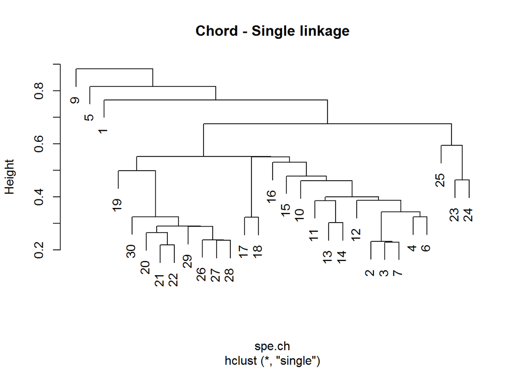

```r
spe.ch.single <- hclust(spe.ch, method = "single") # 单连接聚合聚类分析（层次聚类）
plot(spe.ch.single, # 使用默认选项绘制树形图
  labels = rownames(spe),
  main = "Chord - Single linkage"
  )
```

> 1. 思考关于位点 1, 5, 9 ?
> 2. 单一的简单梯度? 易区分的位点组 ?
> 3. 识别’初级连接链’?

### 4.3.2 Complete Linkage Agglomerative Clustering - 完全连接聚合聚类分析

最远邻排序, 允许一个对象(或一个组)仅以与最远的一对对象对应的不同程度与另一个组进行聚合; 因此, 在最远的一对对象中, 两个组的所有成员都是连接的.

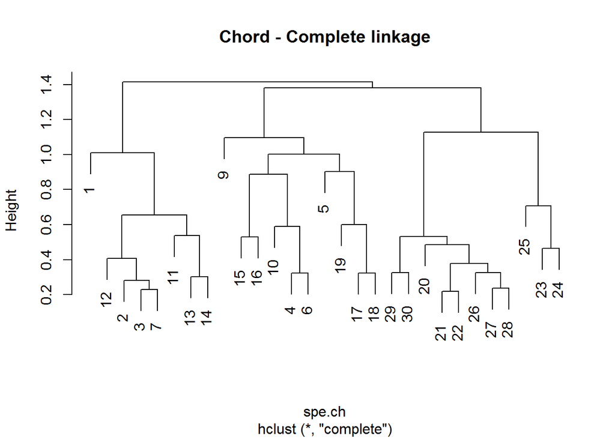

```r
spe.ch.complete <- hclust(spe.ch, method = "complete") # 完全连接聚合聚类分析（层次聚类）
plot(spe.ch.complete, # 使用默认选项绘制树形图
  labels = rownames(spe),
  main = "Chord - Complete linkage")
```

> 1. 思考关于位点 1, 5, 9 ?
> 2. 思考: 两种不同的方式产生的不一样的聚类结果……
> 3. 聚类的分布情况与位点在河流中的分布有哪些异同?

通过对单连接聚合聚类分析方法和完全连接聚合聚类分析方法, 两种方法的结果和内在的分析理解各不相同. 因为与组中的单个对象的连接很容易诱导融合,因此单一连接可以允许对象很容易地聚合到一个组. 也可以将上述过程称之为’最亲密朋友过程’. 单连接聚合聚类分析的树形图并不总能明显地区分出分离的类群, 但是可以很轻松地识别数据间的’梯度’. 相反, 完全连接聚合聚类分析结果则更能明显地显示类群之间的差异. 一个类群分支只接纳与类群最远目标相对应的新成员需要类群全部对象的一致同意. 由此可知, 相关的类群会越来越大, 同时接纳新对象作为类群的新成员的难度也越发困难. 因此该方法通常便于产生很多小的独立群体. 该方法对于搜索和识别数据中的不连续性是很有帮助.

## 4.4 Average Agglomerative Clustering - 平均聚合聚类分析

基于对象之间的平均相异程度或者类群的质心, 具体的平均聚合聚类分析共有 4 中方法. 方法之间的不同之处源于两方面: 一是计算类群位置采用的方法(是根据算数平均值还是根据类群质心); 二是当计算融合水平时, 根据所包含的对象数量是否应该对类群进行加权或者不加权重.

|  | **Arithmetic average** | **Centroid clustering** |
| --- | --- | --- |
| Equal weights | Unweighted pair-group method using arithmetic averages (UPGMA) “average” | Unweighted pair-group method using centroids (UPGMC) “centroid” |
| Unequal weights | Weighted pair-group method using arithmetic averages (WPGMA)“mcquitty” | Weighted pair-group method using centroids (WPGMC) “median” |

最为熟知的一种方法是’UPGMA’: 根据该对象与待融入类群的每个成员之间的平均相异距离判断是否融入该类群. 当两个类群进行融合时, 会根据两个类群中每个成员与另一个类群所有成员的平均相异距离进行判断是否相互融合.

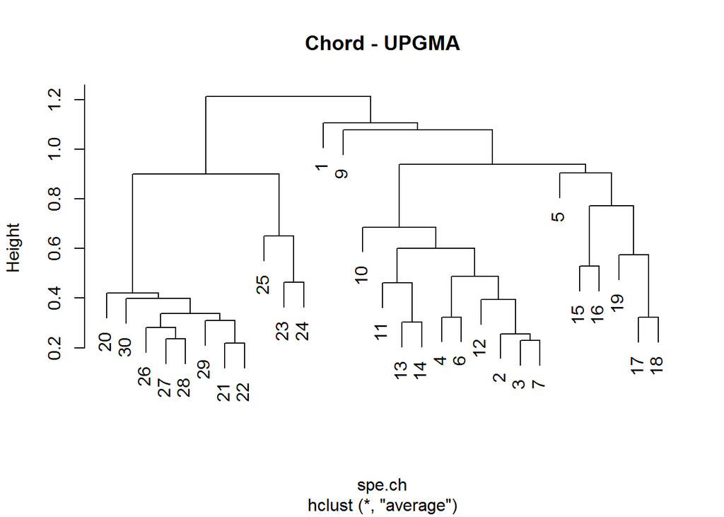

```r
# Unweighted pair-group method using arithmetic averages -- UPGMA
# 使用算术平均值的未加权对组方法
spe.ch.UPGMA <- hclust(spe.ch, method = "average") # 算数平均数聚合聚类
plot(spe.ch.UPGMA,  # 使用默认选项绘制树形图
  labels = rownames(spe),
  main = "Chord - UPGMA")
```

- 聚类分析的结果有些介于单连接聚合聚类分析和完全连接聚合聚类分析结果之间.

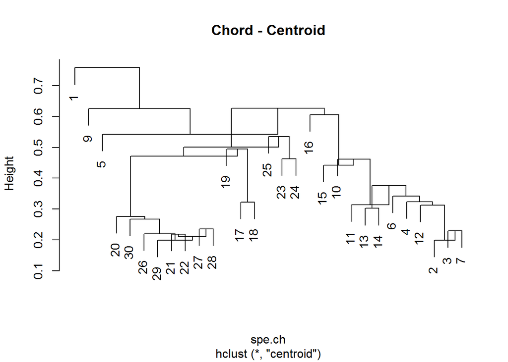

```r
spe.ch.centroid <- hclust(spe.ch, method = "centroid") # 质心聚合聚类
plot(spe.ch.centroid,
  labels = rownames(spe),
  main = "Chord - Centroid")
```

- 对于生态学研究工作者而言, 生成的质心聚合聚类结果难以解释, 基本等同于’噩梦’ – **为什么会产生树形反转**. *如何将树形图划分成几个不同的分区进行解释, 而不是采用’二分法’对聚类结果进行解释*

联合使用 ‘UPGMC’ 和 ‘WPGMC’ 有时会导致树形图反转, 由于不在形成嵌套状的分区, 因此很难对其进行生物学解释.

## 4.5 Ward’s Minimum Variance Clustering - Ward 最小方差聚类

该方法是基于最小二乘法线性模型计算的, 根据组内平方和最小化确定分组. 聚类簇内方差和(sum of squared errors)等于簇内成员间距离的平方和除以对象的数量. 虽然组内方差和是基于 Euclidean 模型计算的, 但是 Ward 方法由相异距离产生有意义的结果并非只有 Euclidean 模型一种选择.

本章将介绍两种不同的 ward 最小方差聚类方法: 一种实现了 Ward’s (1963) 最小方差聚类模型(hclust – method = “ward.D2”), 另一种则没有实现(hclust – method = “ward.D”).

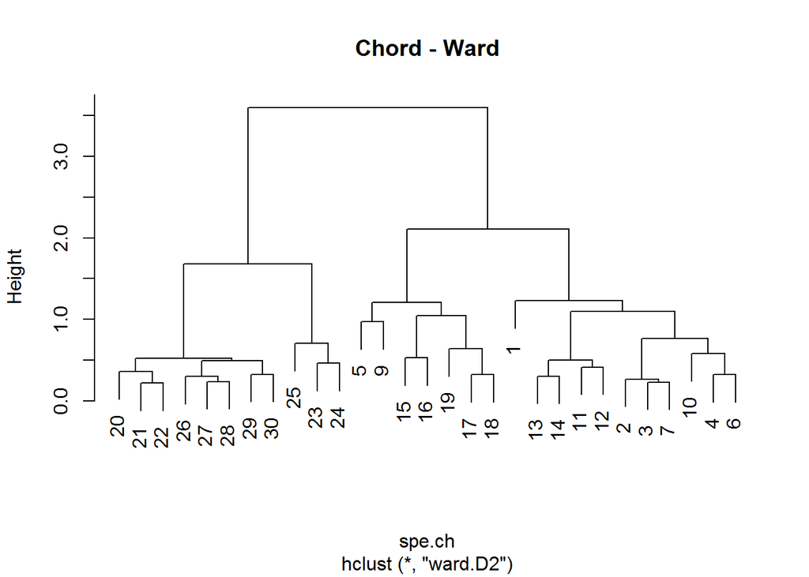

```r
spe.ch.ward <- hclust(spe.ch, method = "ward.D2") # Ward最小方差聚类
plot(spe.ch.ward,  # 使用默认选项绘制树形图 - 直接使用 hclust 对象 | 亦可使用 as.dendrogram() 转换成树形图对象进行绘制
  labels = rownames(spe),
  main = "Chord - Ward")
```

## 4.6 Flexible Clustering - 柔性聚类

通过改变 4 个参数值来实现前文所提到的所有聚类分析模型(Lance and Williams algorithm).

- hclust() – stats 分析包
- agnes() – cluster 分析包: 参数 par.method 可以接受 3 种不同长度的向量( 1 - αh; 3 - αh, αi, β, 同时 γ = 0; 4 )

**αh = αi = (1 - β)/2**

```r
spe.ch.beta1 <- agnes(spe.ch, method = "flexible",par.method = 0.55) # 柔性聚类 - beta = -0.1
spe.ch.beta2 <- agnes(spe.ch, method = "flexible",par.method = 0.625) # 柔性聚类 - beta = -0.25
spe.ch.beta3 <- agnes(spe.ch, method = "flexible",par.method = 0.75) # 柔性聚类 - beta = -0.5
class(spe.ch.beta1) # 查看类别 | 后面更改类别
```

```
## [1] "agnes" "twins"
```

```r
spe.ch.beta1 <- as.hclust(spe.ch.beta1)
class(spe.ch.beta1)
```

```
## [1] "hclust"
```

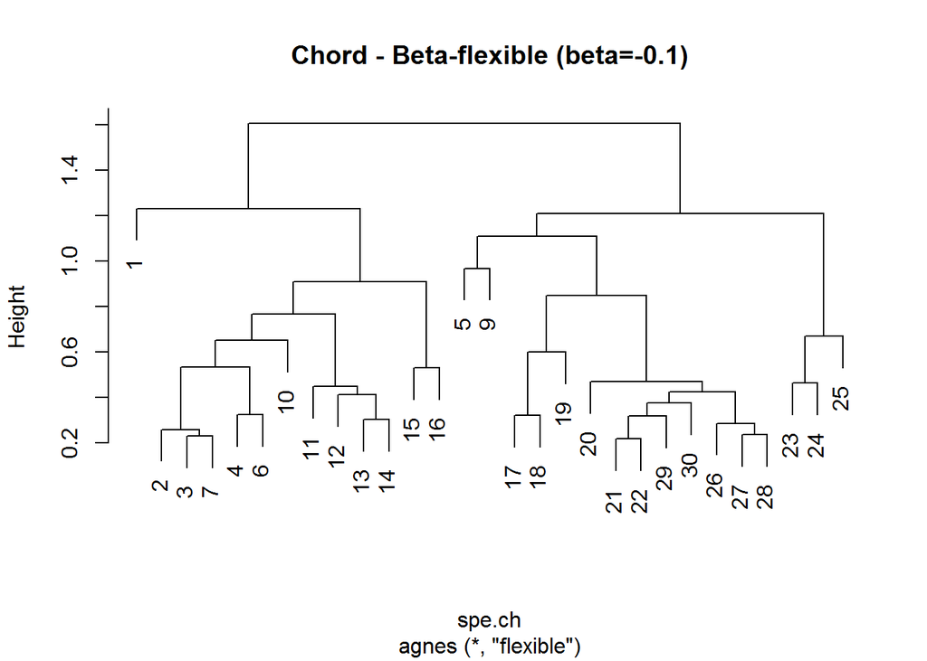

```r
spe.ch.beta2 <- as.hclust(spe.ch.beta2)
spe.ch.beta3 <- as.hclust(spe.ch.beta3)
# 与 前文的 Ward 最小方差聚类方法进行比较
plot(spe.ch.beta1, # 使用默认选项绘制树形图
  labels = rownames(spe),
  main = "Chord - Beta-flexible (beta=-0.1)")
```

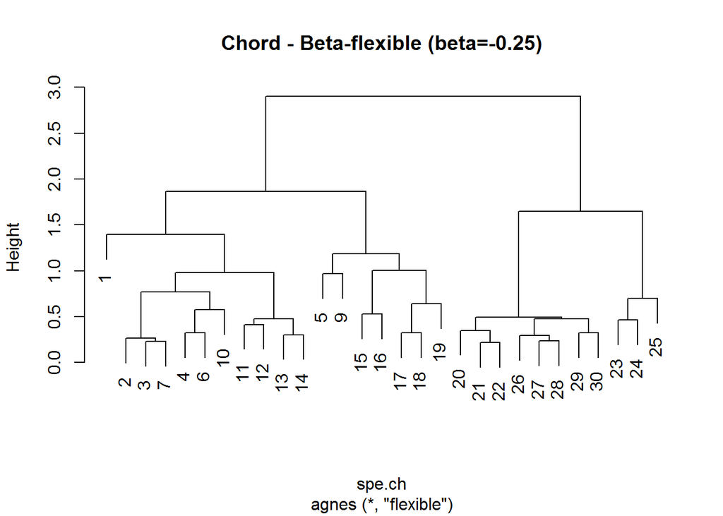

```r
# 与 前文的 Ward 最小方差聚类方法进行比较
plot(spe.ch.beta2, # 使用默认选项绘制树形图
  labels = rownames(spe),
  main = "Chord - Beta-flexible (beta=-0.25)")
```

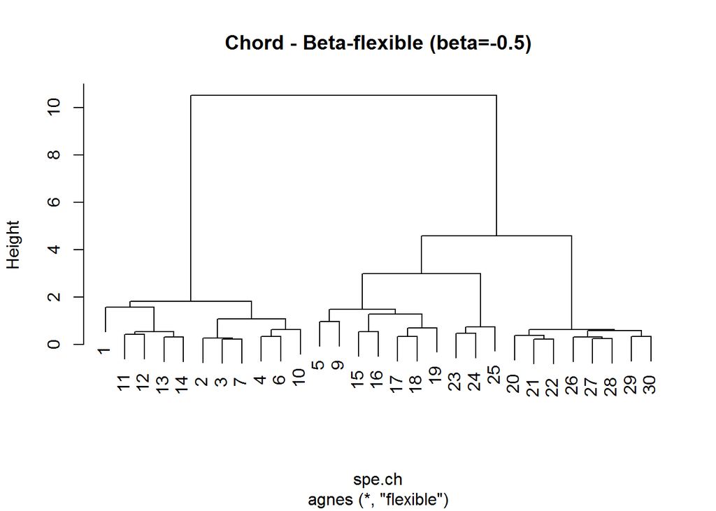

```r
# 与 前文的 Ward 最小方差聚类方法进行比较
plot(spe.ch.beta3, # 使用默认选项绘制树形图
  labels = rownames(spe),
  main = "Chord - Beta-flexible (beta=-0.5)")
```

> 串联分析上述 3 幅聚类结果图, 分析 beta 对树形结构的影响

## 4.7 Interpreting and Comparing Hierarchical Clustering Results - 层次聚类结果的解释与比较

### 4.7.1 简介

**无约束性聚类是一种启发式过程, 并不是统计检验(或者说是聚类分析是一种探索性分析, 不是统计检验).** 关联系数和聚类方法的选择将直接影响对聚类结果的判断. 方法的选择与分析目的直接相关. 可以通过 **summary(‘聚类分析结果对象’)** 来查看聚类结果的诸多信息, 进而作出合理的选择.

### 4.7.2 Cophenetic Correlation - 同表型相关

在树形图中,两个对象之间的同表型距离就是相同组(簇)中两个成员间的距离. 树形图中的两个对象, 从任意一个出发, 沿着树形结构向上,遇到节点之后再向下, 会遇到第二个对象. 同表型矩阵代表了对象之间所有成员结对的同表型距离. 可以通过原始的相异矩阵和童标星矩阵计算 Pearson 相关性(同表型相关性). 具有最高同表型相关性的方法可以视为保留相异矩阵中大部分信息的聚类模型.

由于同表型矩阵来源于原始的相异矩阵(这两种距离数据集并不是相互的独立事件), 因此不可以使用同表型相关性进行显著性检验. 同时, 同表型相关性对聚类方法的选择非常依赖.

使用 stats 分析包中的 [cophenetic()](https://www.rdocumentation.org/packages/stats/versions/3.5.3/topics/cophenetic) 功能函数计算 4 种不同聚类结果的同表型矩阵和同表型相关性.

```r
# https://www.rdocumentation.org/packages/stats/versions/3.5.3/topics/cophenetic
# https://en.wikipedia.org/wiki/Cophenetic_correlation
spe.ch.single.coph <- cophenetic(spe.ch.single) # 单连接聚类（层次聚类） - Single linkage clustering
cor(spe.ch, spe.ch.single.coph) # 相关性分析 - 默认方法'pearson'
```

```
## [1] 0.599193
```

```r
spe.ch.comp.coph <- cophenetic(spe.ch.complete) # 完全连接聚类（层次聚类） - Complete linkage clustering
cor(spe.ch, spe.ch.comp.coph) # 相关性分析 - 默认方法'pearson'
```

```
## [1] 0.7655628
```

```r
spe.ch.UPGMA.coph <- cophenetic(spe.ch.UPGMA) # 均值连接聚类 - Average clustering
cor(spe.ch, spe.ch.UPGMA.coph) # 相关性分析 - 默认方法'pearson'
```

```
## [1] 0.8608326
```

```r
spe.ch.ward.coph <- cophenetic(spe.ch.ward) # Ward聚类
cor(spe.ch, spe.ch.ward.coph) # 相关性分析 - 默认方法'pearson'
```

```
## [1] 0.7998516
```

为了说明不相似矩阵和从各种方法获得的一组共生矩阵之间的关系，可以绘制 Shepard-like 图(数据点之间距离的散点图 – 是实际或变换的邻近度与预测的邻近度的关系图。该图表示多维尺度图表反映实际接近度的程度 – ) [Ref-1](https://www.jmp.com/support/help/14-2/shepard-diagram.shtml) [Ref-2](http://www.mgs.md.gov/coastal_geology/shepards.html)

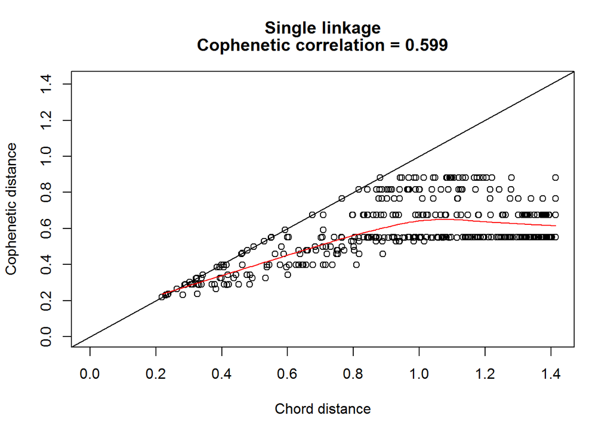

```r
# Shepard-like diagrams - 绘制原始的相异性与共生距离
plot(
  spe.ch,
  spe.ch.single.coph,
  xlab = "Chord distance",
  ylab = "Cophenetic distance",
  xlim = c(0, sqrt(2)),
  ylim = c(0, sqrt(2)),
  main = c("Single linkage",
           paste("Cophenetic correlation =",
                 round(cor(spe.ch, spe.ch.single.coph), 3)
                 )
           )
  )
abline(0, 1) # 为当前图表添加一条或多条直线 - 截距和斜率
# lowess 散点图平滑
# https://www.rdocumentation.org/packages/gplots/versions/3.0.1.1/topics/lowess
lines(lowess(spe.ch, spe.ch.single.coph),
      col = "red")
```

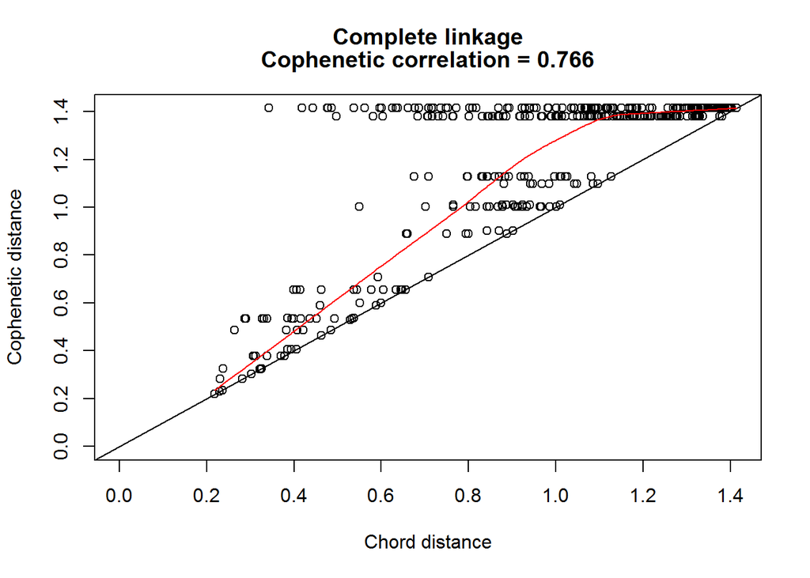

```r
plot(
  spe.ch,
  spe.ch.comp.coph,
  xlab = "Chord distance",
  ylab = "Cophenetic distance",
  xlim = c(0, sqrt(2)),
  ylim = c(0, sqrt(2)),
  main = c("Complete linkage",
           paste("Cophenetic correlation =",
                 round(cor(spe.ch, spe.ch.comp.coph), 3)
                 )
           )
  )
abline(0, 1)# 为当前图表添加一条或多条直线 - 截距和斜率
# lowess 散点图平滑
# https://www.rdocumentation.org/packages/gplots/versions/3.0.1.1/topics/lowess
lines(lowess(spe.ch, spe.ch.comp.coph),
      col = "red")
```

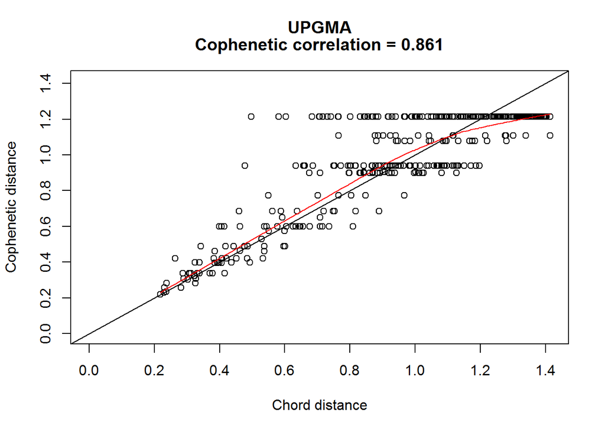

```r
plot(
  spe.ch,
  spe.ch.UPGMA.coph,
  xlab = "Chord distance",
  ylab = "Cophenetic distance",
  xlim = c(0, sqrt(2)),
  ylim = c(0, sqrt(2)),
  main = c("UPGMA",
           paste("Cophenetic correlation =",
                 round(cor(spe.ch,spe.ch.UPGMA.coph), 3)
                 )
           )
  )
abline(0, 1)  # 为当前图表添加一条或多条直线 - 截距和斜率
# lowess 散点图平滑
# https://www.rdocumentation.org/packages/gplots/versions/3.0.1.1/topics/lowess
lines(lowess(spe.ch, spe.ch.UPGMA.coph),
      col = "red")
```

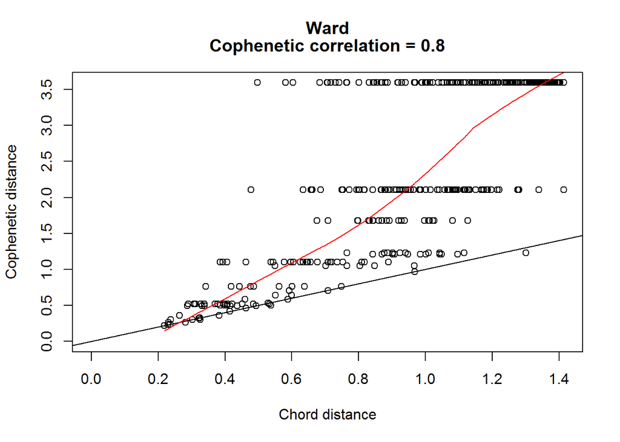

```r
plot(
  spe.ch, # X
  spe.ch.ward.coph, # Y
  xlab = "Chord distance",
  ylab = "Cophenetic distance",
  xlim = c(0, sqrt(2)),
  ylim = c(0, max(spe.ch.ward$height)),
  main = c("Ward", paste("Cophenetic correlation =",
                         round( cor(spe.ch, spe.ch.ward.coph), 3)
                         )
           )
  )
abline(0, 1)  # 为当前图表添加一条或多条直线 - 截距和斜率
# lowess 散点图平滑
# https://www.rdocumentation.org/packages/gplots/versions/3.0.1.1/topics/lowess
lines(lowess(spe.ch, spe.ch.ward.coph),
      col = "red")
```

使用 Gower 距离进行聚类分析, 并进行统计比较(原始相异矩阵和同表型距离之间的平方差之和). 产生最小 Gower 距离的聚类方法可被视为对相异矩阵的最优聚类模型. 同表型相关性和 Gower 距离准则并不是总会将相同的聚类结果视为最好(评价结果并不一致). *命令行置于括号之中, 会立即显示执行结果*

```r
(gow.dist.single <- sum((spe.ch - spe.ch.single.coph) ^ 2)) # Gower (1983) distance
```

```
## [1] 95.41391
```

```r
(gow.dist.comp <- sum((spe.ch - spe.ch.comp.coph) ^ 2)) # Gower (1983) distance
```

```
## [1] 40.48897
```

```r
(gow.dist.UPGMA <- sum((spe.ch - spe.ch.UPGMA.coph) ^ 2)) # Gower (1983) distance
```

```
## [1] 11.6746
```

```r
(gow.dist.ward <- sum((spe.ch - spe.ch.ward.coph) ^ 2)) # Gower (1983) distance
```

```
## [1] 1252.687
```

### 4.7.3 Looking for Interpretable Clusters - 寻找可解释的聚类簇

选择可解释的聚类结果进行比较和解释, 这就意味着需要按照什么样的标准对聚类结果进行筛选(对于树形图如何进行修剪). 尽管并非必须将整个树形图选择单一的切割水平(树木图的某些部分可能比其他部分更具有可解释性), 但通常需要选择到一个或几个可解释性的聚类水平. 选择的可解释性水平可以从树形图的直观结构进行定义, 同时也可以进行自定义某些标准进行选择(比如确定每个聚类簇的成员数量). 在任何时候, 通过添加树形图有关的信息或者绘制有关聚类结果的其他附加信息都有助于对分析结果的整体理解.

#### 4.7.3.1 Graph of the Fusion Level Values - 融合水平值图

树形图的融合水平值是树形图中发生融合的两个分支的相异值. 通过可视化融合水平值相关的信息, 有助于确定对树形图剪切(裁剪或者分割)的水平.

**如何对融合水平值图进行解读???**

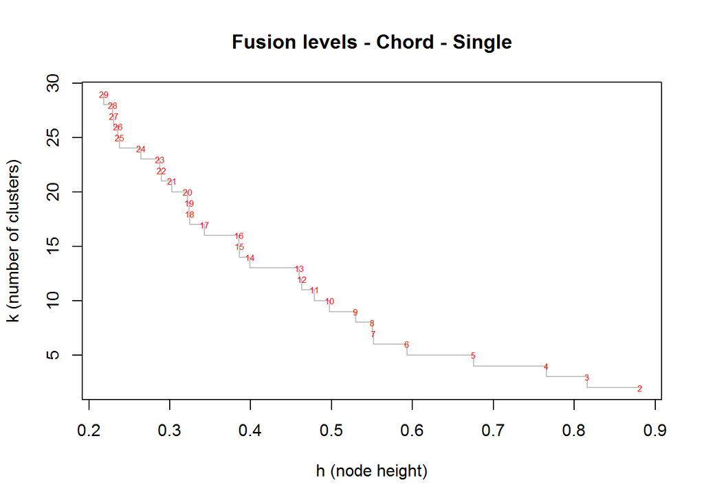

```r
plot(spe.ch.single$height, # 单连接聚合聚类（层次聚类）
     nrow(spe):2,
     type="S", # 阶梯绘图 - S 先垂直后水平，s 则相反
     main="Fusion levels - Chord - Single",
     ylab="k (number of clusters)",
     xlab="h (node height)",
     col="grey")
text(spe.ch.single$height,
     nrow(spe):2,
     nrow(spe):2,
     col="red",
     cex=0.5) # 标签字体大小
```

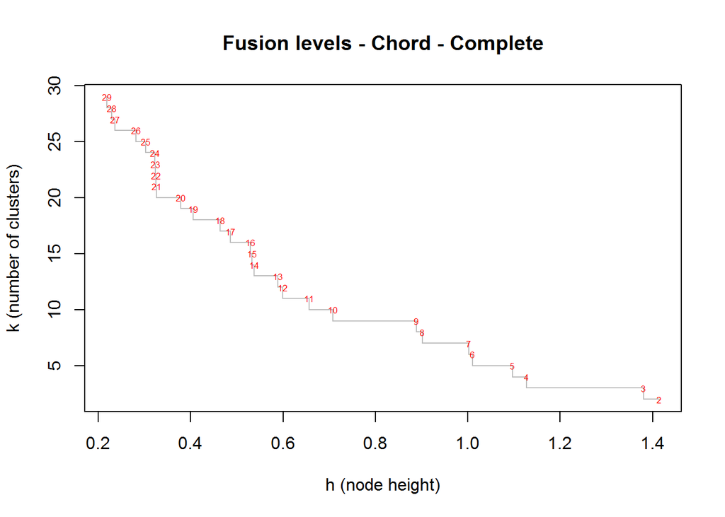

```r
plot(
  spe.ch.complete$height, # 完全连接聚合聚类（层次聚类）
  nrow(spe):2,
  type = "S", # 阶梯绘图 - S 先垂直后水平，s 则相反
  main = "Fusion levels - Chord - Complete",
  ylab = "k (number of clusters)",
  xlab = "h (node height)",
  col = "grey")
text(spe.ch.complete$height,
     nrow(spe):2,
     nrow(spe):2,
     col = "red",
     cex = 0.5) # 标签字体大小
```

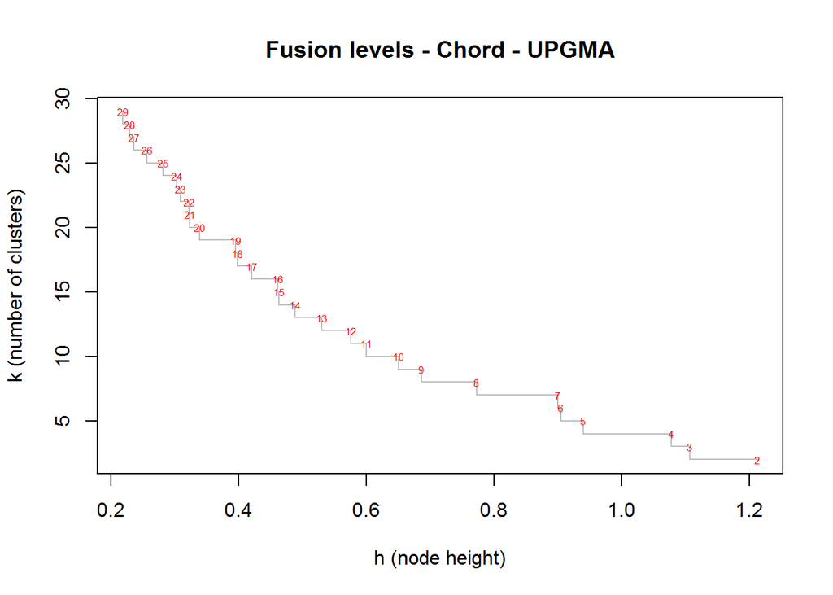

```r
plot(
  spe.ch.UPGMA$height, # 算数平均数的非 - 非加权聚类
  nrow(spe):2,
  type = "S", # 阶梯绘图 - S 先垂直后水平，s 则相反
  main = "Fusion levels - Chord - UPGMA",
  ylab = "k (number of clusters)",
  xlab = "h (node height)",
  col = "grey")
text(spe.ch.UPGMA$height,
     nrow(spe):2,
     nrow(spe):2,
     col = "red",
     cex = 0.5) # 标签字体大小
```

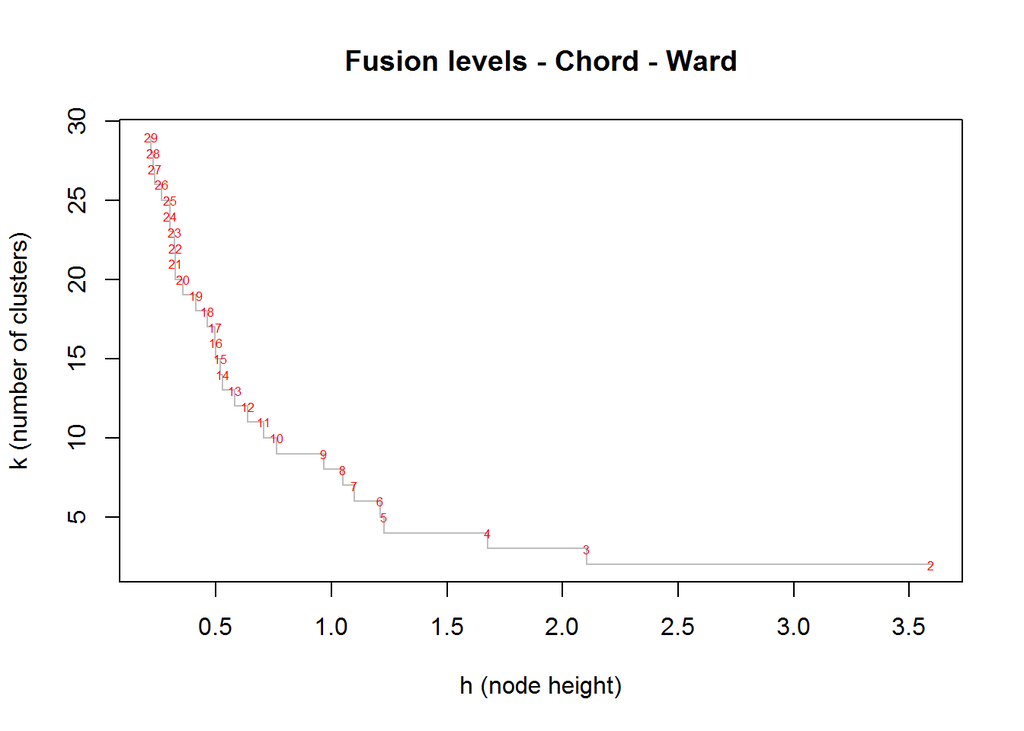

```r
plot(
  spe.ch.ward$height, # Ward聚类
  nrow(spe):2,
  type = "S", # 阶梯绘图 - S 先垂直后水平，s 则相反
  main = "Fusion levels - Chord - Ward",
  ylab = "k (number of clusters)",
  xlab = "h (node height)",
  col = "grey")
text(spe.ch.ward$height,
     nrow(spe):2,
     nrow(spe):2,
     col = "red",
     cex = 0.5) # 标签字体大小
```

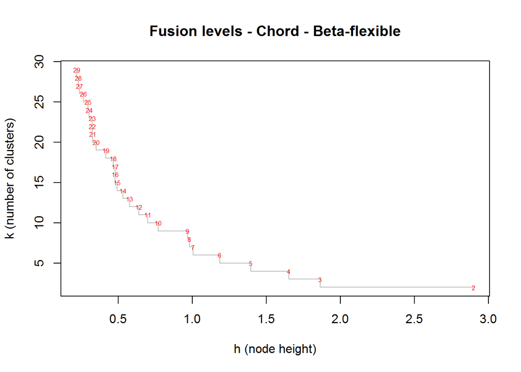

```r
plot(
  spe.ch.beta2$height, # 柔性聚类 - beta = -0.25
  nrow(spe):2,
  type = "S", # 阶梯绘图 - S 先垂直后水平，s 则相反
  main = "Fusion levels - Chord - Beta-flexible",
  ylab = "k (number of clusters)",
  xlab = "h (node height)",
  col = "grey")
text(spe.ch.beta2$height,
     nrow(spe):2,
     nrow(spe):2,
     col = "red",
     cex = 0.5) # 标签字体大小
```

使用 cutree() 对确定分组数量的树形图进行剪裁, 并通过列联表进行比较分析. 如果两个分类中含有相同的成员组分, 那么在列联表的列方向和行方向上只有一个非零频率值. (单连接聚合聚类的两组中的26个位点分布在 ward 最小方差聚类分析结果的 4 4个组中)

```r
k <- 4  # 设置分组数量
# 剪切树形图
spech.single.g <- cutree(spe.ch.single, k = k)
spech.complete.g <- cutree(spe.ch.complete, k = k)
spech.UPGMA.g <- cutree(spe.ch.UPGMA, k = k)
spech.ward.g <- cutree(spe.ch.ward, k = k)
spech.beta.g <- cutree(spe.ch.beta2, k = k)

# class(spe.ch.single)
# [1] "hclust"
# class(spech.single.g)
# [1] "integer"

# 通过列联表进行比较分析
# 使用交叉分类因子来构建每个因子水平组合的计数的列联表
table(spech.single.g, spech.complete.g) # Single vs complete linkage
```

```
##               spech.complete.g
## spech.single.g 1 2 3 4
##              1 1 0 0 0
##              2 7 8 8 3
##              3 0 1 0 0
##              4 0 1 0 0
```

```r
table(spech.single.g, spech.UPGMA.g) # Single linkage vs UPGMA
```

```
##               spech.UPGMA.g
## spech.single.g  1  2  3  4
##              1  1  0  0  0
##              2  0 15  0 11
##              3  0  1  0  0
##              4  0  0  1  0
```

```r
table(spech.single.g, spech.ward.g) # Single linkage vs Ward
```

```
##               spech.ward.g
## spech.single.g  1  2  3  4
##              1  1  0  0  0
##              2 10  5  8  3
##              3  0  1  0  0
##              4  0  1  0  0
```

```r
table(spech.complete.g, spech.UPGMA.g) # Complete linkage vs UPGMA
```

```
##                 spech.UPGMA.g
## spech.complete.g 1 2 3 4
##                1 1 7 0 0
##                2 0 9 1 0
##                3 0 0 0 8
##                4 0 0 0 3
```

```r
table(spech.complete.g, spech.ward.g) # Complete linkage vs Ward
```

```
##                 spech.ward.g
## spech.complete.g 1 2 3 4
##                1 8 0 0 0
##                2 3 7 0 0
##                3 0 0 8 0
##                4 0 0 0 3
```

```r
table(spech.UPGMA.g, spech.ward.g) # UPGMA vs Ward
```

```
##              spech.ward.g
## spech.UPGMA.g  1  2  3  4
##             1  1  0  0  0
##             2 10  6  0  0
##             3  0  1  0  0
##             4  0  0  8  3
```

```r
table(spech.beta.g, spech.ward.g) # beta-flexible vs Ward
```

```
##             spech.ward.g
## spech.beta.g  1  2  3  4
##            1 11  0  0  0
##            2  0  7  0  0
##            3  0  0  8  0
##            4  0  0  0  3
```

#### 4.7.3.2 Compare Two Dendrograms to Highlight Common Subtrees - 比较两个树形图以凸显出公共子树

通过比较树形图和寻找公共聚类簇(共同聚类簇)有助于发现使用几种不同方法找到的分区. dendextend 分析包中的 tangelgram() 函数可以实现上述诉求.

```r
# 凸显公共子树
# 进行对象类别的转换
class(spe.ch.ward) # 查看类别，与后面进行比较
```

```
## [1] "hclust"
```

```r
dend1 <- as.dendrogram(spe.ch.ward) # 重新定义类别 - 树形图
class(dend1) # 查看类别
```

```
## [1] "dendrogram"
```

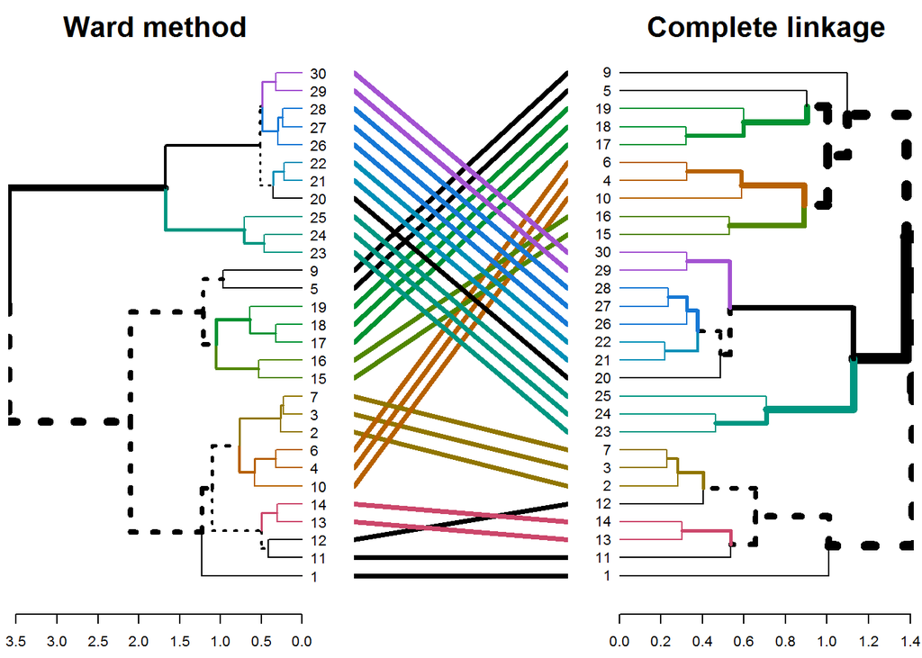

```r
dend2 <- as.dendrogram(spe.ch.complete)
dend12 <- dendlist(dend1, dend2) # 合并多个树状图
tanglegram( #绘制并排树的缠结图
  untangle(dend12), # 解开树形图
  sort = T, # 默认 False ；排序的目的是什么？
  common_subtrees_color_branches = TRUE,
  main_left = "Ward method", # 左侧树形标题
  main_right = "Complete linkage" # 右侧树形标题
  )
```

*位点的信息会尽可能的匹配到两个树形图种, 相同的彩色表征相同的聚类簇, 黑色则说明在两个树中的不同位置. 如何确定稳健的分类簇?*

#### 4.7.3.3 Multiscale Bootstrap Resampling - 多尺度的自举重取样

作为启发式方法(heuristic methods)的非约束性聚类分析并不可用于检验先验假设(priori hypotheses). 然而, 聚类结果很可能反映出’自然变异导致的取样变异’这一问题. 因此, 进一步评估分类结果的不确定性合情合理. (这种评估方式在系统发育分析中已经得到了广泛应用)

采用自展重采样的分析方法验证聚类结果的可靠性, 该方法通过建立随机抽样子集并计算进行分析. 在多次重复聚类分析之后, 计算给定类群在重复聚类结果中出现的频率, 该频率值被称为该聚类簇的自展频率值(bootstrap probability, BP). 在该方法中, 使用不同大小的自展样本计算每个聚类簇的 p 值. 这种改进方法产生了 AU(approximately unbiased, 近乎无偏差) p 值. (树形图中的频率值与聚类簇的稳健性正相关)

*函数 pvclust() 的输入数据必须是转置后的相关数据(行方向保存的是变量信息)*

```r
head(t(spe.norm)) # 查看下文使用的数据信息
```

```
##      1         2         3         4         5         6         7
## Cogo 0 0.0000000 0.0000000 0.0000000 0.0000000 0.0000000 0.0000000
## Satr 1 0.7071068 0.5735393 0.4558423 0.1825742 0.3779645 0.6063391
## Phph 0 0.5656854 0.5735393 0.5698029 0.2738613 0.5039526 0.4850713
## Babl 0 0.4242641 0.5735393 0.5698029 0.1825742 0.6299408 0.6063391
## Thth 0 0.0000000 0.0000000 0.0000000 0.0000000 0.0000000 0.0000000
## Teso 0 0.0000000 0.0000000 0.0000000 0.0000000 0.0000000 0.0000000
##              9        10        11        12        13        14        15
## Cogo 0.0000000 0.0000000 0.1856953 0.2461830 0.2373563 0.2941742 0.2822163
## Satr 0.0000000 0.1543033 0.5570860 0.6154575 0.5933908 0.4902903 0.3762883
## Phph 0.1386750 0.6172134 0.7427814 0.4923660 0.5933908 0.4902903 0.3762883
## Babl 0.4160251 0.6172134 0.1856953 0.4923660 0.2373563 0.3922323 0.4703604
## Thth 0.0000000 0.0000000 0.1856953 0.2461830 0.3560345 0.3922323 0.1881442
## Teso 0.0000000 0.0000000 0.0000000 0.0000000 0.2373563 0.2941742 0.3762883
##             16         17        18         19         20         21
## Cogo 0.1740777 0.09284767 0.1031421 0.00000000 0.00000000 0.00000000
## Satr 0.2611165 0.18569534 0.1031421 0.00000000 0.00000000 0.00000000
## Phph 0.2611165 0.37139068 0.3094264 0.26516504 0.07624929 0.07071068
## Babl 0.4351941 0.37139068 0.3094264 0.44194174 0.15249857 0.07071068
## Thth 0.0000000 0.09284767 0.1031421 0.00000000 0.00000000 0.00000000
## Teso 0.4351941 0.18569534 0.1031421 0.08838835 0.00000000 0.00000000
##              22 23 24 25         26         27         28         29 30
## Cogo 0.00000000  0  0  0 0.00000000 0.00000000 0.00000000 0.00000000  0
## Satr 0.00000000  0  0  0 0.00000000 0.00000000 0.00000000 0.05352877  0
## Phph 0.00000000  0  0  0 0.00000000 0.00000000 0.00000000 0.05352877  0
## Babl 0.06108472  0  0  0 0.09325048 0.06637233 0.06154575 0.05352877  0
## Thth 0.00000000  0  0  0 0.00000000 0.00000000 0.00000000 0.05352877  0
## Teso 0.00000000  0  0  0 0.00000000 0.00000000 0.00000000 0.05352877  0
```

```r
# 通过多尺度自展重取样分析带有 p-value 的层次聚类
# 计算聚类树形图中所有类的 p-value
# http://stat.sys.i.kyoto-u.ac.jp/prog/pvclust/
spech.pv <- pvclust(t(spe.norm), # 使用转置的标准化后的数据集
                    method.hclust = "ward.D2", # 聚类的方法 - ward 最小方差分析
                    method.dist = "euc", # 计算距离的方法 - euclidean
                    parallel=TRUE)
```

```
## Creating a temporary cluster...done:
## socket cluster with 7 nodes on host 'localhost'
## Multiscale bootstrap... Done.
```

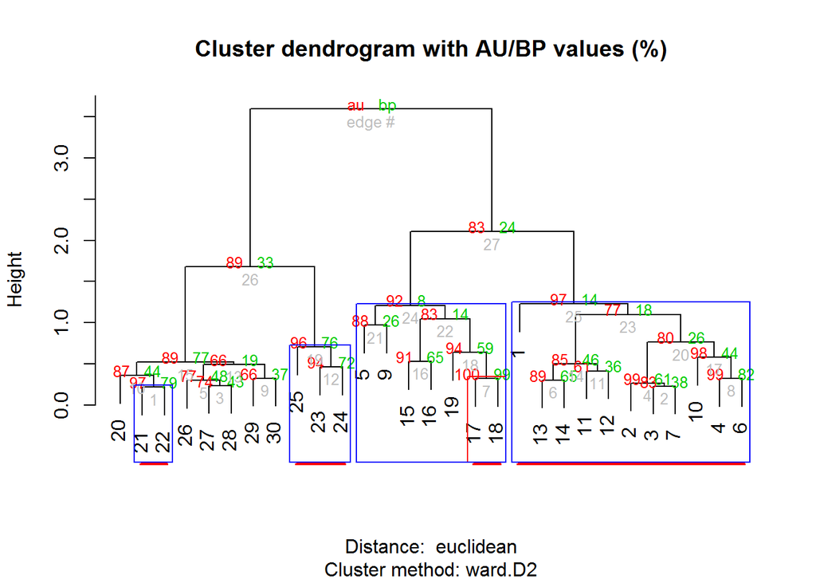

```r
# AU p-value (red) - "approximately unbiased" p-value, calculated by multiscale bootstrap resampling.
# BP value (green) - "bootstrap probability" value, less accurate than AU value as p-value.
# clusters (edges) with high AU values (e.g. 95%) are strongly supported by data
plot(spech.pv) # 使用默认选项绘制带有 p-value 的树形图

# 凸显具有高 au p-values 值的聚类
pvrect(spech.pv, # Find Clusters with High/Low P-values | 导入数据是 pcvlust 对象
       alpha = 0.95,
       pv = "au")
lines(spech.pv) # 添加线
pvrect(spech.pv,
       alpha = 0.91,
       border = 4) # 矩形的边框宽度
```

一旦我们确定了树形图结构并意欲评估聚类簇的稳健性, 可以通过’轮廓宽度 - silhouette widths’,’矩阵比较 - matrix comparison’和’鉴别物种 - diagnostic species’三种方式来确定聚类分析结果的适当聚类组数量.

#### 4.7.3.4 Average Silhouette Widths - 平均轮廓宽度

轮廓宽度是描述对象与聚类簇之间的成员关系的一种度量方式, 通过该对象与所属聚类簇成员对象的平均相异距离来进行表征; 可以通过轮廓宽度与下一个最邻近的聚类簇进行比较. 轮廓宽度的变化范围在 -1 ~ 1 之间, 能平均覆盖到一个分区的所有对象.

使用 cluster 分析包中的 silhouette() 函数功能进行平均轮廓宽度分析, 该功能提供了一个轮廓宽度的正式定义: 数值越大, 对象的聚类结果越好. 负值则表示相对应的对象聚类位置有所不妥.

在每个融合水平, 平均轮廓宽度可被用作分区质量好坏的评估标准: 计算轮廓宽度, 也就意味着需要考量对象和组之间的关系强度, 选择一个组内的融合水平也就意味着对象和组内之间的关系强度最大.

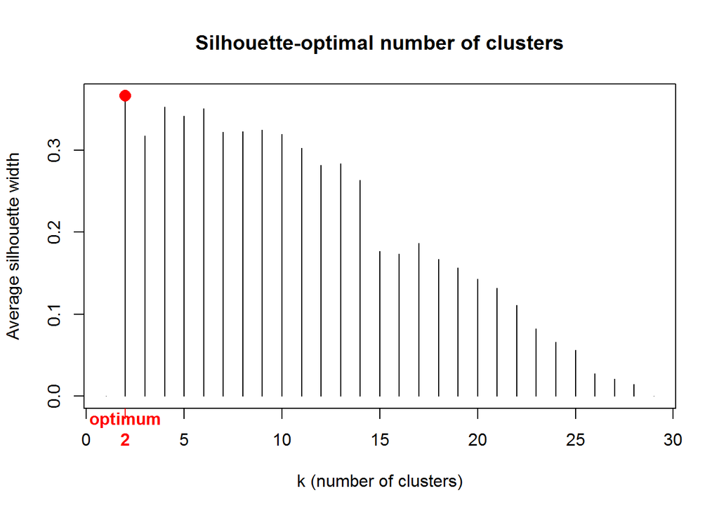

```r
# 选择合适的聚类数量 - 分别针对三种不同聚类分析的数据集
hc <- spe.ch.ward # 重命名 hclust 对象 - ward 最小方差分析聚类
# hc <- spe.ch.beta2 # 柔性聚类
# hc <- spe.ch.complete # 完全连接聚合聚类
# 平均轮廓宽度分析 (Rousseeuw 质量指数)
Si <- numeric(nrow(spe)) # 强制数值类型转换
for (k in 2:(nrow(spe) - 1)) {
  # silhouette - 提取轮廓信息
  sil <- silhouette(cutree(hc, k = k), # 根据簇数切分树形 并返回数值化向量
                    spe.ch) # spe.ch - 弦距离矩阵
  Si[k] <- summary(sil)$avg.width
  }
k.best <- which.max(Si)
plot(
  1:nrow(spe),
  Si,
  type = "h", # '高密度'垂直线
  main = "Silhouette-optimal number of clusters",
  xlab = "k (number of clusters)",
  ylab = "Average silhouette width")
axis( 1, # 哪一侧绘制轴: 1 下; 2 左; 3 上; 4 右
  k.best, # 目标点在轴上的位置
  paste("optimum", k.best, sep = "\n"),
  col = "red",
  font = 2,
  col.axis = "red")
points(k.best, # 描绘目标点的位置
       max(Si), # 目标点的数值
       pch = 16,
       col = "red",
       cex = 1.5)
```

- 该如何理解分区中的两组? 生态学的观点又是怎样的?

#### 4.7.3.5 Comparison Between the Dissimilarity Matrix and Binary Matrices Representing Partitions - 比较表示分区块的相异矩阵和二进制矩阵

比较分析原始的相异矩阵和由不同水平剪切的树形图计算而来的二进制矩阵(二元’有-无’矩阵). 选取两矩阵相关性最高的剪切水平(或者说是’融合水平’) 由于矩阵之间并不是相互相互独立的, 所以对选取的结果进行检测几乎不可能. 实际上, 与分区结果相关的矩阵都是从原始的相异矩阵提取的.

使用 grpdist() 函数计算表示组成员之间关系的二进制相异矩阵(二元’有-无’矩阵).

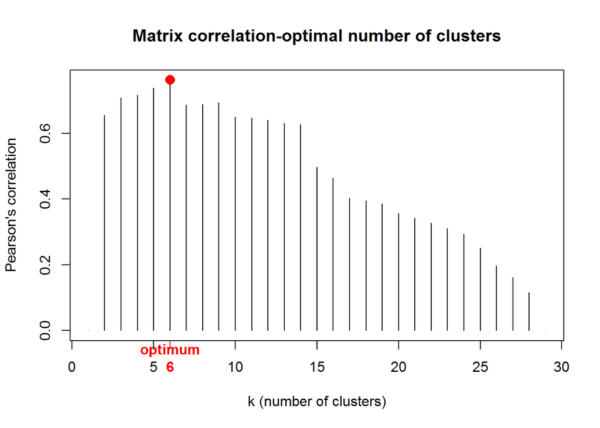

```r
# 根据相异矩阵的相关性分析(Pearson)选择最优的聚类数量
kt <- data.frame(k = 1:nrow(spe), r = 0)
#hc <- spe.ch.ward # 重命名 hclust 对象 - ward 最小方差分析聚类
#spe.ch - 弦距离矩阵
for (i in 2:(nrow(spe) - 1)) {
  gr <- cutree(hc, i) # 根据簇数切分树形图 并生成数值化向量
  # https://github.com/JoeyBernhardt/NumericalEcology/blob/master/NEwR%20functions/supplementary/grpdist.R
  distgr <- grpdist(gr) # 计算向量的相异二元矩阵(二进制矩阵)
  mt <- cor(spe.ch, distgr, # spe.ch - 弦距离矩阵
            method = "pearson") # 计算 pearson 相关性系数
  kt[i, 2] <- mt }
k.best <- which.max(kt$r)
plot(
  kt$k,
  kt$r,
  type = "h", # '高密度'垂直线
  main = "Matrix correlation-optimal number of clusters",
  xlab = "k (number of clusters)",
  ylab = "Pearson's correlation")
axis( 1, # 哪一侧绘制轴: 1 下; 2 左; 3 上; 4 右
  k.best, # 目标点在轴上的位置
  paste("optimum", k.best, sep = "\n"),
  col = "red",
  font = 2,
  col.axis = "red")
points(k.best,  # 描绘目标点的位置
       max(kt$r), # 目标点的数值
       pch = 16,
       col = "red",
       cex = 1.5)
```

#### 4.7.3.6 Species Fidelity Analysis - 物种的保真度分析

基于物种保真度来评估分区结果的质量是另一个内部标准. 这种分析方法的一个基本观点是要保留一组经过系列’诊断性’物种特征化的簇, 这一类成员也被称为’指示者’‘典型值’’特征值’或者’特异值’物种, 这些物种在给定的位点中分布更加频繁和丰富. 具体来说, 最好的分区应该具有以下两个特征: 1) 最大化指示者值的总和, 2) 最大化具有重要指示种的簇的比例. (IndVal, 指示者参量)

- **‘条形图’中的’绿色’部分表示’按照该方案分区将得到重要的指示物种’**

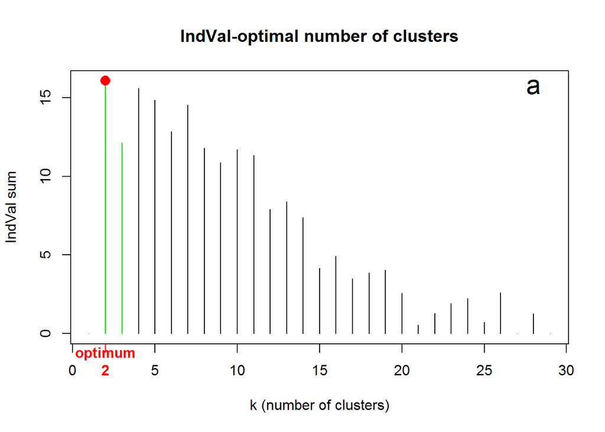

```r
# 根据对每个指示性物种的分析选择最优的聚类数量
# IndVal, Dufrene-Legendre; 分析包: labdsv
IndVal <- numeric(nrow(spe)) # 强制数值化定义类别
ng <- numeric(nrow(spe))
for (k in 2:(nrow(spe) - 1)) {
  # 计算集群或类型中物种的指标值(保真度和相对丰度)
  iva <- indval(spe,
                cutree(hc, k = k), # 数值化簇成员的向量
                numitr = 1000) # 迭代次数
  gr <- factor(iva$maxcls[iva$pval <= 0.05]) # 因子化
  ng[k] <- length(levels(gr)) / k
  iv <- iva$indcls[iva$pval <= 0.05]
  IndVal[k] <- sum(iv)
  }
k.best <- which.max(IndVal[ng == 1]) + 1
col3 <- rep(1, nrow(spe)) # 生成重复向量
col3[ng == 1] <- 3

# par(mfrow = c(1, 2))
plot(
  1:nrow(spe),
  IndVal,
  type = "h", # '高密度'垂直线
  main = "IndVal-optimal number of clusters",
  xlab = "k (number of clusters)",
  ylab = "IndVal sum",
  col = col3)
axis(
  1,  # 哪一侧绘制轴: 1 下; 2 左; 3 上; 4 右
  k.best, # 目标点在轴上的位置
  paste("optimum", k.best, sep = "\n"),
  col = "red",
  font = 2,
  col.axis = "red")
points(
  which.max(IndVal),  # 描绘目标点的位置
  max(IndVal),  # 目标点的数值
  pch = 16,
  col = "red",
  cex = 1.5)
text(28, 15.7, # 坐标位置(x,y)
     "a", cex = 1.8)
```

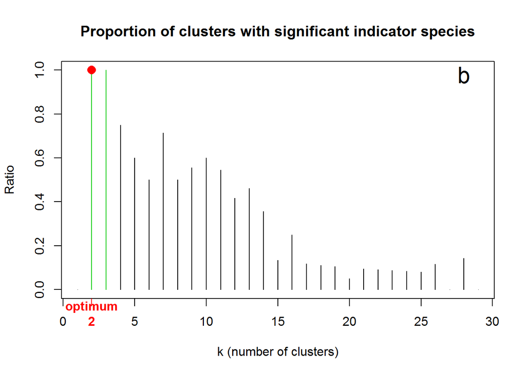

```r
plot(
  1:nrow(spe),
  ng,
  type = "h", # '高密度'垂直线
  xlab = "k (number of clusters)",
  ylab = "Ratio",
  main = "Proportion of clusters with significant indicator species",
  col = col3  )
axis(1,  # 哪一侧绘制轴: 1 下; 2 左; 3 上; 4 右
     k.best, # 目标点在轴上的位置
     paste("optimum", k.best, sep = "\n"),
     col = "red",
     font = 2,
     col.axis = "red")
points(k.best,  # 描绘目标点的位置
       max(ng),  # 目标点的数值
       pch = 16,
       col = "red",
       cex = 1.5)
text(28, 0.98, # 坐标位置(x,y)
     "b", cex = 1.8)
```

> 只有两个分区的结果, 才符合’平均轮廓宽度’和’物种保真度’这两个内在的标准; 但是, 在三或者四个分区结果中, 可能会挖掘出更多的细微结构, 这种情况也是可以接受的(可能无法发现一些差异物种).

#### 4.7.3.7 Silhouette Plot of the Final Partition - 最终的分区块的轮廓图

基于平均轮廓分析,矩阵相关性分析和指示性物种分析等三种不同的方法都没有返回相同的轮廓结构图, 同时, 分区的最佳结果也在 2 ~ 6 之间波动. 一种折中的分类簇数量为 4, 以此继续进行后续的分类组诊断. 选择 ward 最小方差聚类方法进行最后的分析, 该方法可以产生 4 种平衡良好(大小不等, 无异常值)和划分良好的分类组.

- **注意绘图结果的解读**

*分类簇 1 - 3 结果较好, 分类簇 2 有些错分类的对象*

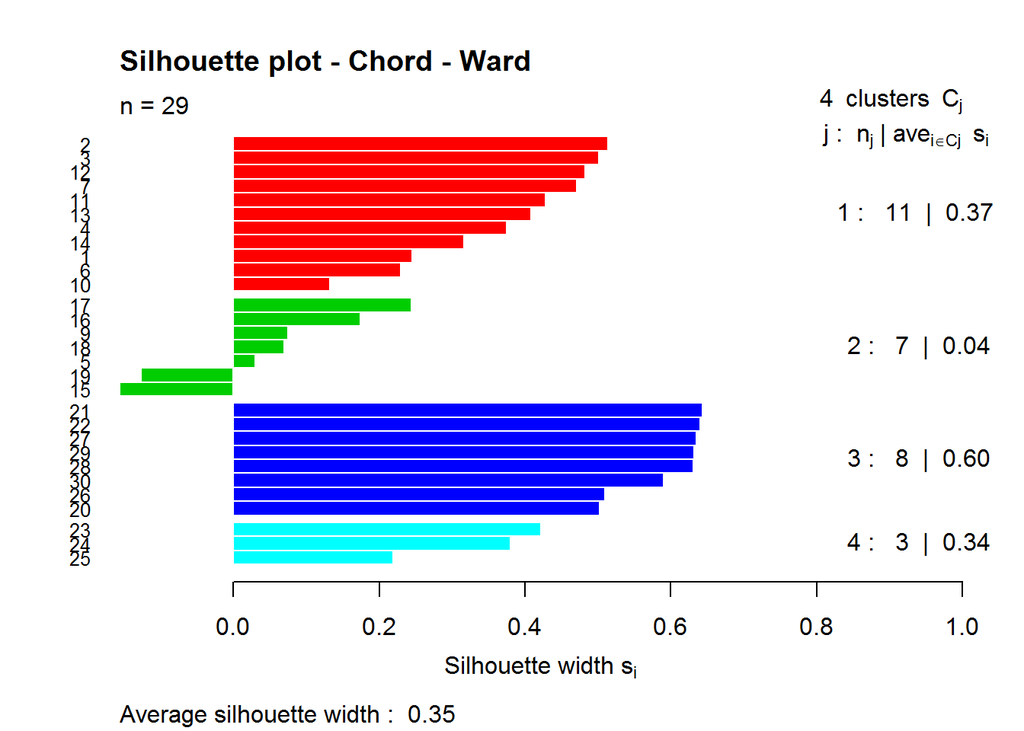

```r
k <- 4 # 设置聚类簇数
# 根据簇数切分树形图 并生成数值化向量
spech.ward.g <- cutree(spe.ch.ward, # ward 最小方差聚类
                       k = k)
# 提取轮廓信息
sil <- silhouette(spech.ward.g,  # 向量
                  spe.ch) # 弦距离矩阵
# class(sil)
# [1] "silhouette"
rownames(sil) <- row.names(spe)
plot(
  sil,
  main = "Silhouette plot - Chord - Ward",
  cex.names = 0.8,
  col = 2:(k + 1),
  nmax = 100  )
```

#### 4.7.3.8 Final Dendrogram with Graphical Options - 带有图形选项的最终树形图

生成含有 4 个分类簇的最终树形图, 绘图过程中修改几个选项以利于最终的结果呈现.

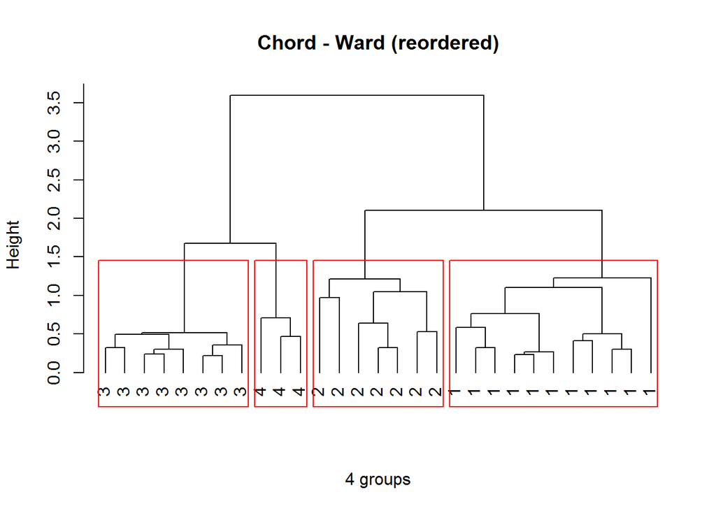

```r
# 按簇类别标记 - 不同的标签
# reorder.hclust() 重新排序对象, 以便可能地照顾到对象在相异矩阵中的原始顺序
spe.chwo <- reorder.hclust(spe.ch.ward, spe.ch)
plot(
  spe.chwo,
  hang = -1,
  xlab = "4 groups",
  sub = "",
  ylab = "Height",
  main = "Chord - Ward (reordered)",
  labels = cutree(spe.chwo, k = k)
  )
# 在分类簇四周绘制矩阵框
rect.hclust(spe.chwo, # 聚类分析的对象
            k = k) # 融合水平 | 分类簇数量
```

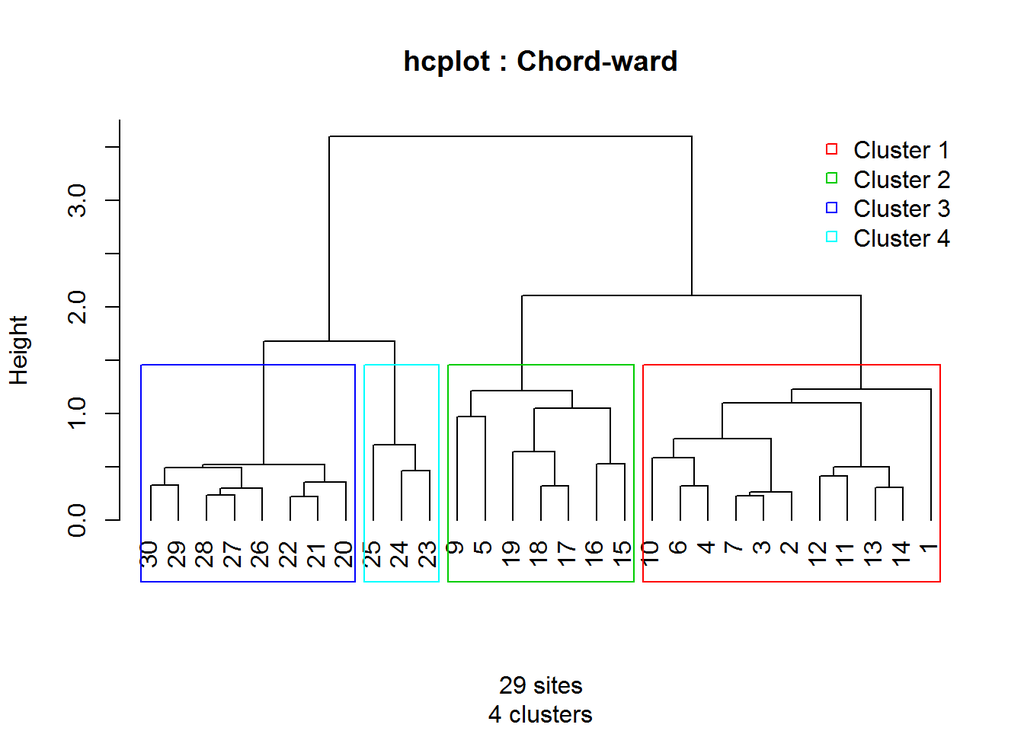

```r
# 使用组和图例的颜色重新排序和绘制树状图
# https://github.com/JoeyBernhardt/NumericalEcology/blob/master/hcoplot.R#L4
hcoplot(spe.ch.ward, # ward 最小方差聚类分析 | 聚类分析的对象
        spe.ch, # 弦距离矩阵
        title = "hcplot : Chord-ward",
        k = 4)
```

使用 dendextend 分析包提高和改善树形图的可视化程度.

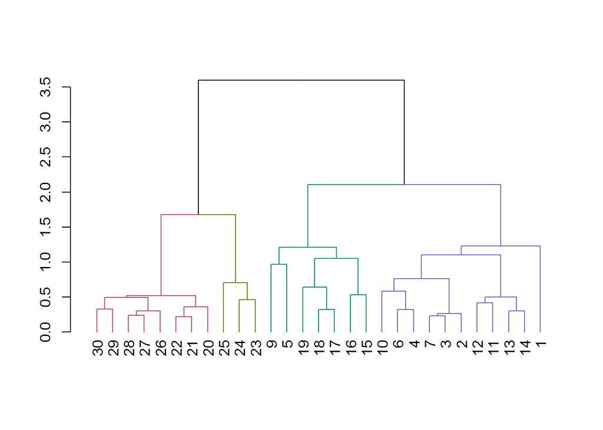

```r
dend <- as.dendrogram(spe.chwo) # 将 hclust 对象 转换成 树形对象(dendrogram)
k = 4 # 设置聚类的簇数

# 1 - 绘制带颜色枝的树形图
dend %>% set("branches_k_color", k = k) %>% plot
```

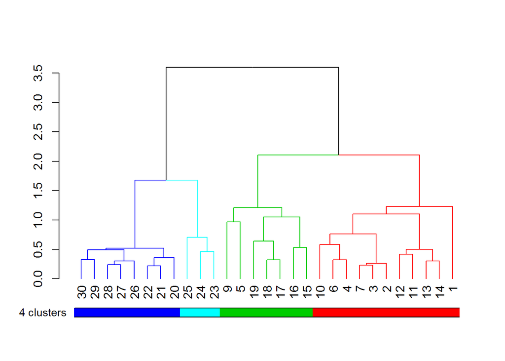

```r
# 2 - 对簇上色(使用标准颜色)
# order.dendrogram(dend) # 叶子的顺序/标签
clusters <- cutree(dend, k)[order.dendrogram(dend)] # 按照簇数切分树形图对象并再次按照标签重新排列生成新向量
dend %>% set("branches_k_color",
             k = k, value = unique(clusters) + 1) %>% plot  # 绘制带颜色枝的树形图
colored_bars(clusters + 1, # 坐标轴位置
             y_shift = -0.5, # 坐标轴位置
             rowLabels = paste(k, "clusters")) # 颜色行列名
```

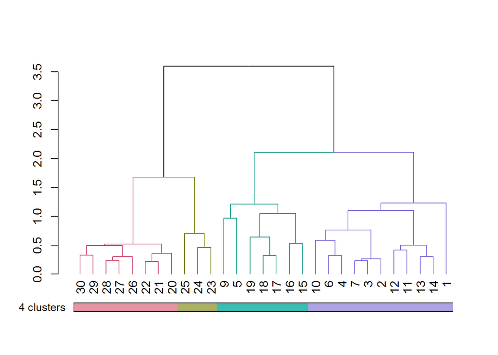

```r
# 3 - 绘制颜色条形图
clusters <- cutree(dend, k)[order.dendrogram(dend)] # 按照簇数切分树形图对象并再次按照标签重新排列生成新向量
dend %>% branches_attr_by_clusters(clusters) %>% plot # 绘制带颜色枝的树形图
cols <- rainbow_hcl(k) # 生成 k 个颜色向量
ord_cols <- rainbow_hcl(k)[order(unique(clusters))]
tmp_cols  <- rep(1, length(clusters)) # 生成重复向量
tmp_cols[clusters != 0] <- ord_cols[clusters != 0][clusters]
colored_bars(tmp_cols, # 坐标轴位置
             y_shift = -0.5,  # 坐标轴位置
             rowLabels = paste(k, "clusters")) # 颜色行列名
```

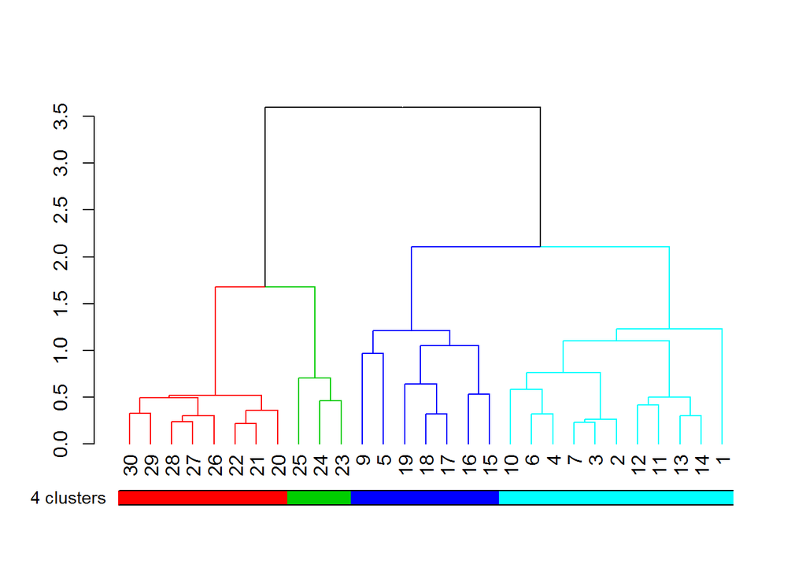

```r
# 4 - 使用标准颜色
cols <- 2:(k + 1)
# > clusters[2]
# 29
#  3
# unique(clusters) # 获取向量集合 - 唯一
# order(unique(clusters)) # 重新排序??
ord_cols <- cols[order(unique(clusters))]
tmp_cols  <- rep(1, length(clusters))  # 生成重复向量
tmp_cols[clusters != 0] <- ord_cols[clusters != 0][clusters]
dend %>% branches_attr_by_clusters(clusters, values = cols) %>% plot  # 绘制带颜色枝的树形图
colored_bars(tmp_cols, # 坐标轴位置
             y_shift = -0.5,  # 坐标轴位置
             rowLabels = paste(k, "clusters")) # 颜色行列名
```